# Weight Lifting Exercise

Stefan Buchholz

August 2014

# Task-Description

In this project, my goal was to use data from accelerometers on the belt, forearm, arm, and dumbell of 6 participants. They were asked to perform barbell lifts correctly and incorrectly in 5 different ways. More information is available from the website here: http://groupware.les.inf.puc-rio.br/har (see the section on the Weight Lifting Exercise Dataset). The aim is to predict the outcome of “classe”-variable with the given variables in the training-dataset.

# Dataset-Description

The dataset that was downloaded on 24th of August 2014 from the following link: https://d396qusza40orc.cloudfront.net/predmachlearn/pml-training.csv describes weight lifting exercises from 6 people. The Dataset contains 19622 observations of 160 variables where the last feature “classes” is an indicator how correct the exercise was done.

The variables in the dataset consists on different datatypes as factors, numerical and integer values. The ranges of the last types are in a negative through a postive range with a lot of NA values.

# Getting the Data

The data was accessed on 24th of August at 17:45 GMT+1 since the given 20 test-cases are for the submission only I will only show how I get the training-data.

```r
library(RCurl)
```

```r
#Windows specific workaround
options(RCurlOptions = list(cainfo = system.file("CurlSSL", "cacert.pem", package = "RCurl")))
#Training data
url <- "https://d396qusza40orc.cloudfront.net/predmachlearn/pml-training.csv"
website <- getURL(url)
raw_dataset <- read.csv(text = website)

#test data
url_test <- "https://d396qusza40orc.cloudfront.net/predmachlearn/pml-testing.csv"
website <- getURL(url_test)
test <- read.csv(text = website)
```

# Viewing the Data

I started to view the data which I downloaded yet. There are no freaky column-names to clean but a lot of empty rows in a lot of variables.

```r
dim(raw_dataset)
```

```
## [1] 19622   160
```

```r
colnames(raw_dataset)
```

```
##   [1] "X"                        "user_name"
##   [3] "raw_timestamp_part_1"     "raw_timestamp_part_2"
##   [5] "cvtd_timestamp"           "new_window"
##   [7] "num_window"               "roll_belt"
##   [9] "pitch_belt"               "yaw_belt"
##  [11] "total_accel_belt"         "kurtosis_roll_belt"
##  [13] "kurtosis_picth_belt"      "kurtosis_yaw_belt"
##  [15] "skewness_roll_belt"       "skewness_roll_belt.1"
##  [17] "skewness_yaw_belt"        "max_roll_belt"
##  [19] "max_picth_belt"           "max_yaw_belt"
##  [21] "min_roll_belt"            "min_pitch_belt"
##  [23] "min_yaw_belt"             "amplitude_roll_belt"
##  [25] "amplitude_pitch_belt"     "amplitude_yaw_belt"
##  [27] "var_total_accel_belt"     "avg_roll_belt"
##  [29] "stddev_roll_belt"         "var_roll_belt"
```

[output cut: 65 more lines]

```r
summary(raw_dataset)
```

[output not shown]

[output cut: 289 more lines]

[output not shown]

```r
#str(raw_dataset)
head(raw_dataset)
```

[output not shown]

[output cut: 265 more lines]

# Cleaning the data

```r
# convert columns to get correct NA values
for(i in seq_along(raw_dataset[,5:159])) {
  raw_dataset[,i] <- as.numeric(raw_dataset[,i])
}

#converting columns in testdata
for(i in seq_along(test[,5:159])) {
  test[,i] <- as.numeric(test[,i])
}

y <- NULL
for(i in seq_along(test)) {
  y <- c(y,sum(is.na(test[,i])) > 0)
}

#exclude columns where NAs included
temp <- raw_dataset[,!y]
temp_test <- test[, !y]

#now exclude what doesnt work
data <- temp[, 8:60]
data_test <- temp_test[, 8:60]
```

# Splitting the training data into train and test-set

Once cleaned out the data i seperated the given training data set into 2 by the classe variable into 70% of all train data into a training set and the other 30% into the test set.

```r
library(caret)
intrain <- createDataPartition(y=data$classe, p=0.7, list=FALSE)
training_data <- data[intrain,]
test_data <- data[-intrain,]
```

# Making first model with a Tree model

```r
library(caret)
set.seed(10)
model <- train(classe ~ ., method="rpart", data=training_data)
library(rattle)
```

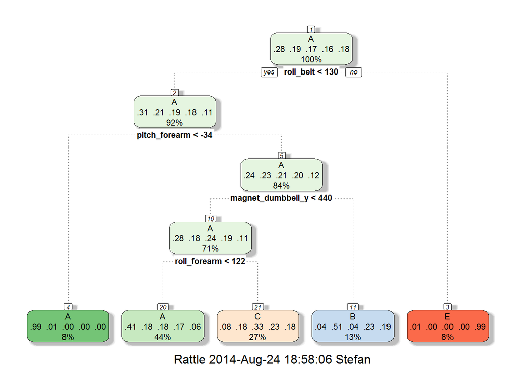

```r
fancyRpartPlot(model$finalModel)
```

```r
#predict it
prediction <- predict(model, newdata=test_data)

#calculate missclassification
xtab <- table(prediction, test_data$classe)
confusionMatrix(xtab)
```

```
## Confusion Matrix and Statistics
##
##
## prediction    A    B    C    D    E
##          A 1527  476  471  426  132
##          B   18  385   32  165  145
##          C  124  278  523  373  298
##          D    0    0    0    0    0
##          E    5    0    0    0  507
##
## Overall Statistics
##
##                Accuracy : 0.5
##                  95% CI : (0.487, 0.513)
##     No Information Rate : 0.284
##     P-Value [Acc > NIR] : <2e-16
##
##                   Kappa : 0.347
##  Mcnemar's Test P-Value : NA
##
## Statistics by Class:
##
##                      Class: A Class: B Class: C Class: D Class: E
## Sensitivity             0.912   0.3380   0.5097    0.000   0.4686
## Specificity             0.643   0.9241   0.7792    1.000   0.9990
## Pos Pred Value          0.504   0.5168   0.3277      NaN   0.9902
## Neg Pred Value          0.948   0.8533   0.8827    0.836   0.8930
## Prevalence              0.284   0.1935   0.1743    0.164   0.1839
## Detection Rate          0.259   0.0654   0.0889    0.000   0.0862
## Detection Prevalence    0.515   0.1266   0.2712    0.000   0.0870
## Balanced Accuracy       0.777   0.6311   0.6445    0.500   0.7338
```

# Making second model with random forest

The random forest model i used was basically with the standard settings of the program showing the most important variables of the model. You can See that the first 30 variables are the most important ones for the random forest model. The accuracy of the model is above 99% percent so this is a pretty accurate model.

For the future I could tweak the model a little bit further to exclude more variables to get an easier model with less variables included.

```r
library(caret)
library(rattle)
library(randomForest)
```

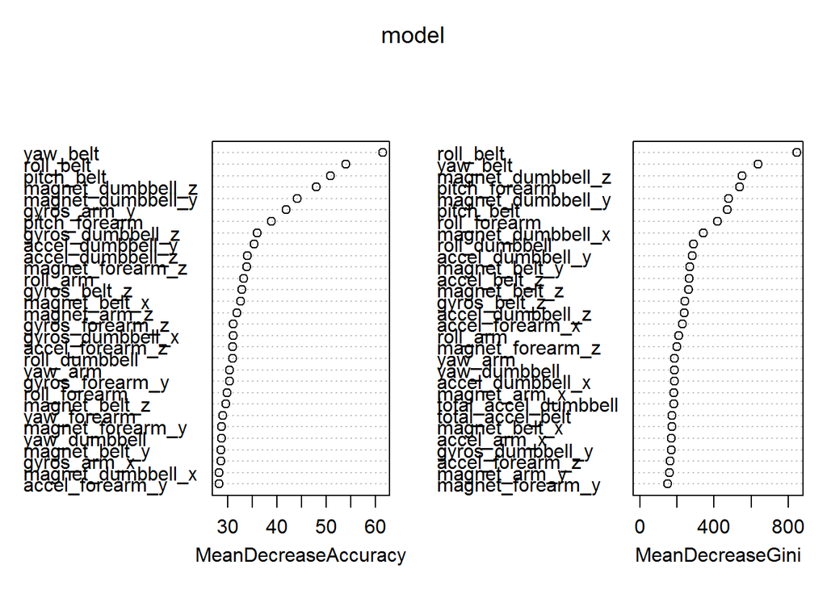

```r
set.seed(10)
model <- randomForest(classe ~ ., importance = TRUE, data = training_data)
varImpPlot(model, scale=TRUE)
```

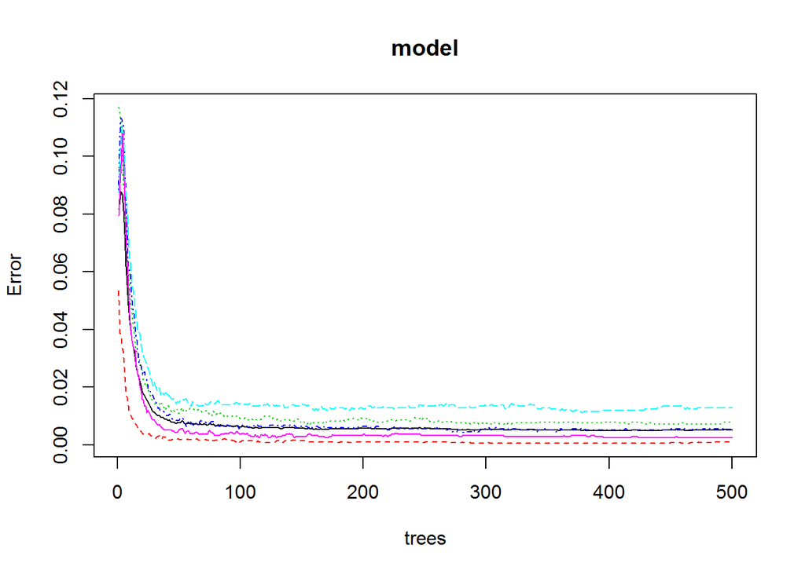

```r
plot(model, legend=TRUE)
```

```r
#prediction
prediction <- predict(model, newdata=test_data)

#calculate missclassification
xtab <- table(prediction, test_data$classe)
confusionMatrix(xtab)
```

```
## Confusion Matrix and Statistics
##
##
## prediction    A    B    C    D    E
##          A 1674    5    0    0    0
##          B    0 1131    9    0    0
##          C    0    3 1017    6    0
##          D    0    0    0  957    1
##          E    0    0    0    1 1081
##
## Overall Statistics
##
##                Accuracy : 0.996
##                  95% CI : (0.994, 0.997)
##     No Information Rate : 0.284
##     P-Value [Acc > NIR] : <2e-16
##
##                   Kappa : 0.995
##  Mcnemar's Test P-Value : NA
##
## Statistics by Class:
##
##                      Class: A Class: B Class: C Class: D Class: E
## Sensitivity             1.000    0.993    0.991    0.993    0.999
## Specificity             0.999    0.998    0.998    1.000    1.000
## Pos Pred Value          0.997    0.992    0.991    0.999    0.999
## Neg Pred Value          1.000    0.998    0.998    0.999    1.000
## Prevalence              0.284    0.194    0.174    0.164    0.184
## Detection Rate          0.284    0.192    0.173    0.163    0.184
## Detection Prevalence    0.285    0.194    0.174    0.163    0.184
## Balanced Accuracy       0.999    0.996    0.995    0.996    0.999
```